# cc1-miashs1et2-b – MA1AY010 Probabilités

Date de publication

16 octobre 2025

**NoteCC I/IV :**

- Licence MIASHS
- 20 Octobre 2025 Durée : 1 heure 15
- **Intégration et Probabilités**

**Exercice 1**

**Partie I**

Dans un étang vivent $N\geqslant 1$ poissons numérotés $1$ à $N$. On pêche le poisson $i$ avec une probabilité $p_i$ ($\sum_{i=1}^N p_i=1$).  
Après avoir noté le numéro du poisson pêché, on le remet (délicatement) à l’eau. On répète cette opération $n\geq 1$ fois. Les opérations sont indépendantes les unes des autres.

1. Proposer un univers, une tribu et une loi sur la tribu pour modéliser ces pêches répétées.
2. Quelle est la probabilité que le poisson $i$ ne soit pas pêché du tout ?
3. Quelle est la probabilité que le poisson $i$ soit pêché au moins $k$ fois?
4. Quelle est la probabilité que le poisson pêché lors de l’épreuve $n$ ait été pêché exactement une fois lors des $n-1$ épreuves précédentes.

**Partie II**

Dans le même étang, au lieu de répéter l’épreuve $n$ fois, on tire d’abord $X$ selon une loi de Poisson de paramètre $n$. Si $X=k$, on effectue ensuite $k$ pêches indépendantes selon la description plus haut.

22. Proposer un univers, une tribu et une loi sur la tribu pour modéliser ces pêches répétées un nombre aléatoire de fois.
6. Montrer que pour chaque poisson $i$, le nombre de captures du poisson $i$ suit une loi de Poisson. Préciser le paramètre de la loi de Poisson. Quelle est la probabilité que le poisson $i$ soit pêché exactement $\ell$ fois?
7. Quelle est la probabilité que le poisson $i$ soit pêché exactement $m$ fois *et* le poisson $j$ soit pêché exactement $m$ fois ?

*Rappel* : la loi de Poisson de paramètre $\mu>0$ est définie par

$$P(\{k\}) = \mathrm{e}^{-\mu} \frac{\mu^k}{k!} \qquad \text{ pour } k \in \mathbb{N}\, .$$

**Exercice 2**

Répondre par *vrai/faux*

- Deux événements disjoints ne peuvent pas être indépendants.
- Un événement ne peut pas être indépendant de lui-même.
- $(A, B, C)$ forment une famille indépendante si et seulement si $(A,B)$, $(A,C)$ et $(B,C)$ sont des paires d’événements indépendants.
- $\cup_n \mathbb{N}^n$ est dénombrable.
- La tribu de parties de $\mathbb{N}$ engendrée par les sous-ensembles finis de $\mathbb{N}$ est dénombrable.
- $f : \mathbb{R} \to \mathbb{R}$ définie par $f(x)=\mathbb{I}_{[0,1]}(x)$ est une loi de probabilité sur $(\mathbb{R}, \mathcal{B}(\mathbb{R}))$.
- Une fonction de répartition atteint toujours la valeur $1$
- Une fonction quantile est continue à droite en tout point.
- L’ensemble des médianes d’une loi de probabilité sur $(\mathbb{R}, \mathcal{B}(\mathbb{R}))$ définit un intervalle.

**Exercice 3**

1. À partir de la figure et de vos connaissances, répondre par *Vrai/Faux* aux questions suivantes.
   - Cette fonction de répartition est associée à une loi discrète
   - La loi associée possède une unique médiane
   - La fonction quantile associée est continue sur $(0,1)$
   - La fonction de répartition est dérivable presque partout.
   - La fonction de répartition est l’intégrale de sa dérivée.
   - La loi associée est une loi sur $[0, \infty)$.
2. Que vaut la fonction quantile en $0.5$?

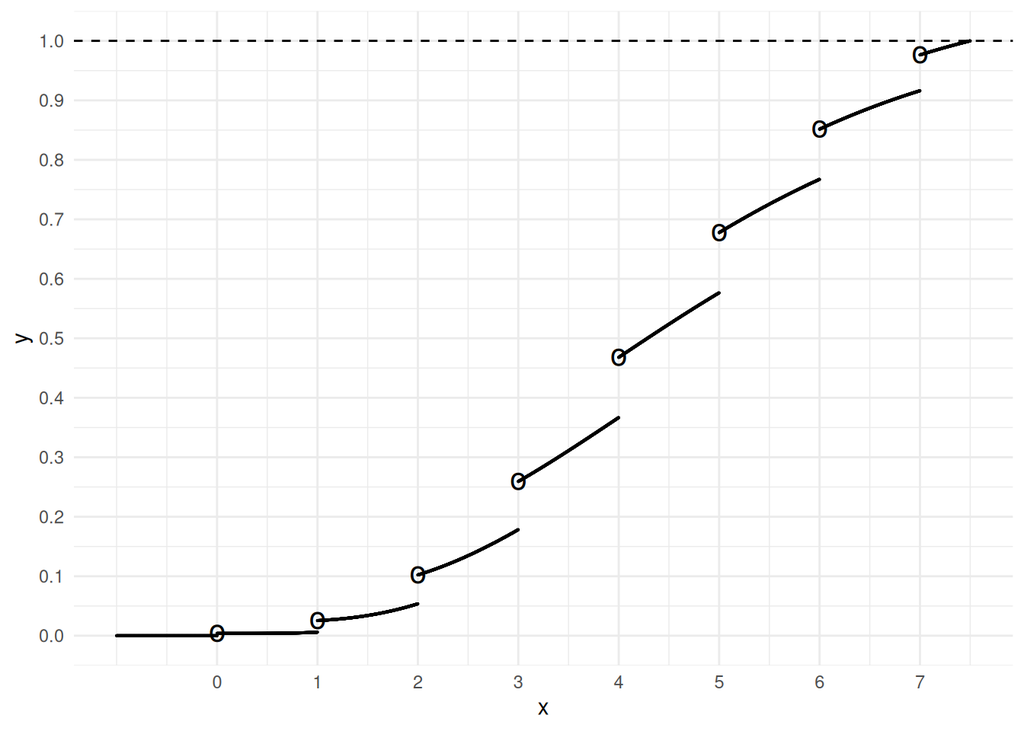

Figure 1